# DATA2002 Module 4 Report

Group 9 (460352996,480407614,480145820,470066919)

```r
library(tidyverse)
library(knitr)
library(janitor)
library("readxl")
library(ggfortify)
library(GGally)
library(qtlcharts)
library(leaps)
library(sjPlot)
library(pheatmap)
library(partykit)
library(rpart)
library(caret)
```

## 1. Introduction

Excess weight, especially obesity, has become an epidemic in the 21st century and resulted in many significant health and economic consequences for the global population (Stein and Colditz, 2004). In Australia, this epidemic has also spread as 2 in 3 adults are classified as overweight or obese (Australian Institute of Health and Welfare). Researches has shown that this epidemic is more common in males than females and hence, BYU Human Performance Research Center has collected data from 250 men of various age and obtained estimates of the percentage of body fat through underwater weighing and various body circumference measurements (Rahman and Harding, 2013; DASL, n.d.). As body fat percentage is difficult to calculate in real life, the value for body fat percentage was derived from body density using the Siri’s 1956 equation.

### 1.1 Sampling method and potential biases

Few details were provided with regards to the sampling method. However, from looking at the dataset, there is a gender bias as the epidemic question is one related to both genders, yet only male were involved in the sample. This suggests that any analysis based on this dataset cannot be applied to the whole population but only the male population.

### 1.2 Data import, processing and cleaning

```r
data = read.delim("bodyfat.txt") %>% janitor::clean_names()
data = data %>%
  mutate(bmi = (data$weight/(data$height ^ 2)) * 703,
         overweight = case_when(
          bmi >= 25 ~ 1,
          bmi < 25 ~ 0))
data$overweight = as.numeric(data$overweight)
#colnames(data)
data_bmi = data[-c(1:2,4:5,18)]
data_bf = data[-c(1,3:5,17:18)]
data_density = data[-c(2:5,17:18)]
data_overweight = data[-c(4:5,17)]
glimpse(data)
```

```
## Observations: 250
## Variables: 18
## $ density    <dbl> 1.0708, 1.0853, 1.0414, 1.0751, 1.0340, 1.0502, 1.054…
## $ pct_bf     <dbl> 12.3, 6.1, 25.3, 10.4, 28.7, 20.9, 19.2, 12.4, 4.1, 1…
## $ age        <int> 23, 22, 22, 26, 24, 24, 26, 25, 25, 23, 26, 27, 32, 3…
## $ weight     <dbl> 154.25, 173.25, 154.00, 184.75, 184.25, 210.25, 181.0…
## $ height     <dbl> 67.75, 72.25, 66.25, 72.25, 71.25, 74.75, 69.75, 72.5…
## $ neck       <dbl> 36.2, 38.5, 34.0, 37.4, 34.4, 39.0, 36.4, 37.8, 38.1,…
## $ chest      <dbl> 93.1, 93.6, 95.8, 101.8, 97.3, 104.5, 105.1, 99.6, 10…
## $ abdomen    <dbl> 85.2, 83.0, 87.9, 86.4, 100.0, 94.4, 90.7, 88.5, 82.5…
## $ waist      <dbl> 33.54331, 32.67717, 34.60630, 34.01575, 39.37008, 37.…
## $ hip        <dbl> 94.5, 98.7, 99.2, 101.2, 101.9, 107.8, 100.3, 97.1, 9…
## $ thigh      <dbl> 59.0, 58.7, 59.6, 60.1, 63.2, 66.0, 58.4, 60.0, 62.9,…
## $ knee       <dbl> 37.3, 37.3, 38.9, 37.3, 42.2, 42.0, 38.3, 39.4, 38.3,…
## $ ankle      <dbl> 21.9, 23.4, 24.0, 22.8, 24.0, 25.6, 22.9, 23.2, 23.8,…
## $ bicep      <dbl> 32.0, 30.5, 28.8, 32.4, 32.2, 35.7, 31.9, 30.5, 35.9,…
## $ forearm    <dbl> 27.4, 28.9, 25.2, 29.4, 27.7, 30.6, 27.8, 29.0, 31.1,…
## $ wrist      <dbl> 17.1, 18.2, 16.6, 18.2, 17.7, 18.8, 17.7, 18.8, 18.2,…
## $ bmi        <dbl> 23.62446, 23.33205, 24.66632, 24.88078, 25.51485, 26.…
## $ overweight <dbl> 0, 0, 0, 0, 1, 1, 1, 0, 0, 1, 0, 1, 1, 1, 1, 1, 1, 1,…
```

### 1.3 Data Visualisation

#### 1.3.1 Obesity and Age

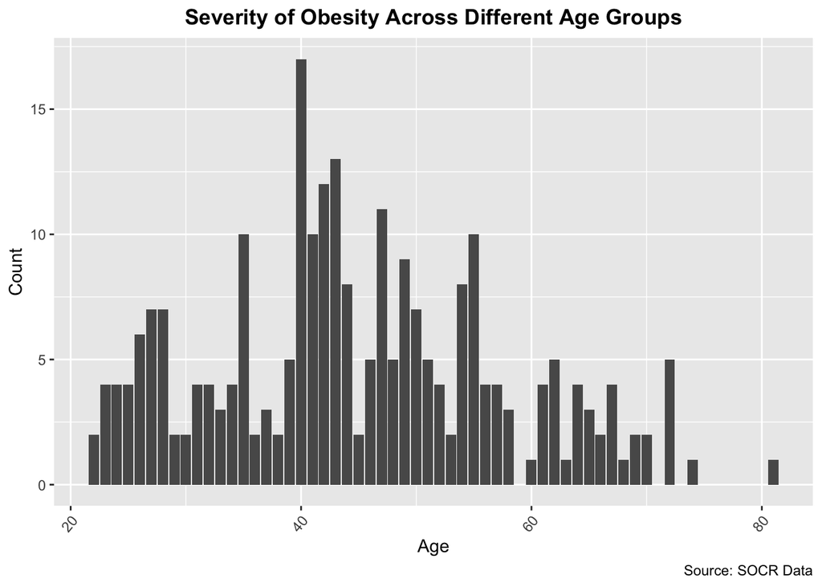

```r
ggplot(data, aes(x=age,fill=overweight)) + geom_bar() +scale_fill_brewer(palette = "Paired") +labs(x='Age',y='Count', title = 'Severity of Obesity Across Different Age Groups',caption='Source: SOCR Data') +theme(plot.title = element_text(hjust = 0.5, face = 'bold'))+theme(axis.text.x = element_text(angle = 50, hjust = 1))+scale_fill_discrete(name = "Overweight", labels = c("Non-Overweight", "Overweight"))
```

#### 1.3.2 Body Measurements

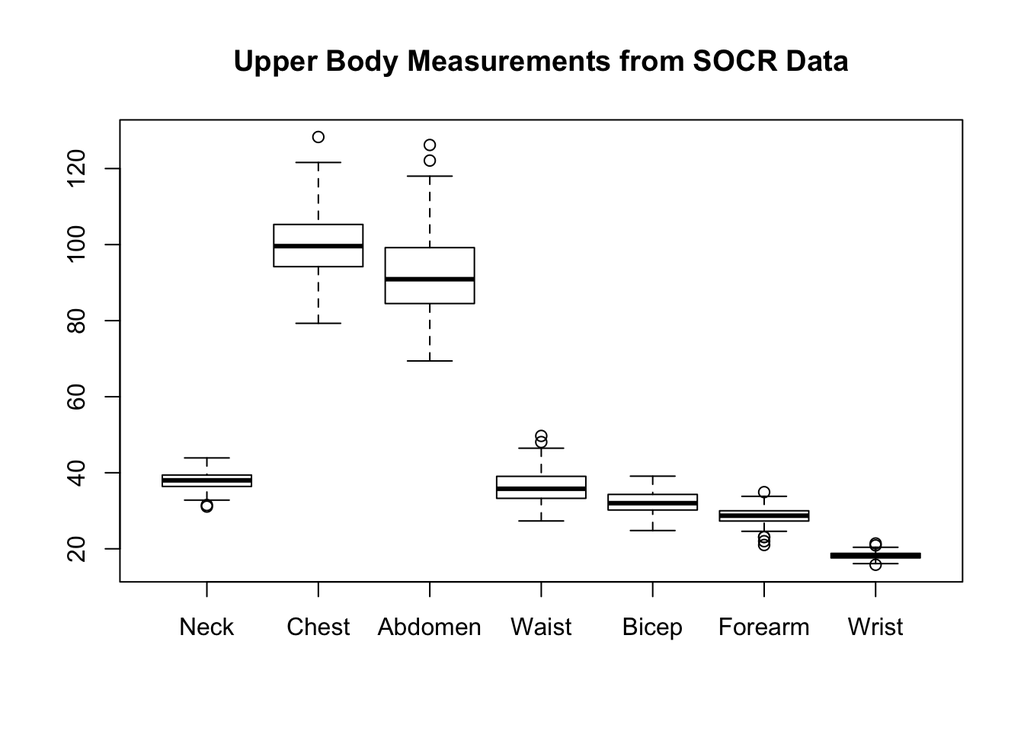

```r
boxplot(data$neck,data$chest,data$abdomen,data$waist,data$bicep,data$forearm,data$wrist,main = "Upper Body Measurements from SOCR Data",names = c("Neck","Chest","Abdomen","Waist","Bicep","Forearm","Wrist"))
```

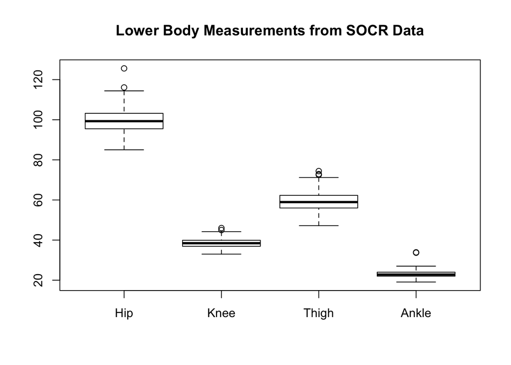

```r
boxplot(data$hip,data$knee,data$thigh,data$ankle,main = "Lower Body Measurements from SOCR Data",names = c("Hip","Knee","Thigh","Ankle"))
```

From the two boxplots, the body measurement dataset appears relatively symmetrical and contains a few outliers. This may propose some problems in the later stages of the analysis.

### 1.4 Analysis Approach

This report aims to determine an alternative method to determine “overweight” individuals oppose to body fat percentage and the two alternative methods considered are:

1. BMI
2. Body Density

The analysis will first begin through determining how much variation in body fat percentage can be explained by simply body measurements and the number of measurements that is significant in building an accurate prediction model to examine the ease of calculation.

Then similar analysis will be conducted on BMI and Body Density where the end result will be compared together to determine which method can be explained the best using simple body measurements and offers easier and simpler interpretation.

## 2. Analysis

Due to the increasing consumptions of fast food and the increasing convenience of food deliveries, concerns about obesity level is rising throughput the world and has reached a new high. This increasing concern has lead to an increasing need to measure obesity accurately and percentage body fat is arguably the most accurate measure by far. However, the calculation of body fat is difficult and many has switched to Body Mass Index (BMI) for simpler calculation. This section is looking at how much variation that simple body measurements can explain in the three methods of interest - body fat percentage, BMI and body density.

### 2.1 Body Fat Percentage

##### 2.1.1 Data Visualisation

```r
qtlcharts::iplotCorr(data_bf)
```

```
## Set screen size to height=700 x width=1000
```

[interactive chart not shown]

Based on the interactive correlation matrix above, it can be seen the level of correlation differs quite drastically between the variables and the backward variable selection method is adopted.

#### 2.1.2 Multiple Regression and Variable Selection

```r
bf_lm = lm(pct_bf~.,data=data_bf)
summary(bf_lm)
```

```
##
## Call:
## lm(formula = pct_bf ~ ., data = data_bf)
##
## Residuals:
##     Min      1Q  Median      3Q     Max
## -9.8684 -2.9088 -0.1904  3.0491 11.1421
##
## Coefficients: (1 not defined because of singularities)
##             Estimate Std. Error t value Pr(>|t|)
## (Intercept)  2.20340    6.83392   0.322  0.74742
## neck        -0.45612    0.23034  -1.980  0.04882 *
## chest       -0.13005    0.09197  -1.414  0.15866
## abdomen      1.03299    0.07638  13.524  < 2e-16 ***
## waist             NA         NA      NA       NA
## hip         -0.33000    0.12768  -2.585  0.01034 *
## thigh        0.08793    0.13395   0.656  0.51217
## knee        -0.13537    0.22744  -0.595  0.55227
## ankle        0.05505    0.21751   0.253  0.80041
## bicep        0.17762    0.17029   1.043  0.29798
## forearm      0.19468    0.20718   0.940  0.34834
## wrist       -1.52499    0.50529  -3.018  0.00282 **
## ---
## Signif. codes:  0 '***' 0.001 '**' 0.01 '*' 0.05 '.' 0.1 ' ' 1
##
## Residual standard error: 4.341 on 239 degrees of freedom
## Multiple R-squared:  0.737,  Adjusted R-squared:  0.726
## F-statistic: 66.98 on 10 and 239 DF,  p-value: < 2.2e-16
```

Using the individual p-value method, the varaibles that need to be dropped are chest, waist, thigh, knee,ankle, bicep, forearm with ankle being the first to drop down due to its high p-value. However, to double check, the AIC criterion will also be considered.

```r
bf_step_back = step(bf_lm, direction = "backward",trace = FALSE)
summary(bf_step_back)
```

```
##
## Call:
## lm(formula = pct_bf ~ neck + chest + abdomen + hip + bicep +
##     wrist, data = data_bf)
##
## Residuals:
##    Min     1Q Median     3Q    Max
## -9.668 -2.889 -0.361  3.210 11.148
##
## Coefficients:
##             Estimate Std. Error t value Pr(>|t|)
## (Intercept)  1.52703    6.63727   0.230 0.818232
## neck        -0.39650    0.22234  -1.783 0.075783 .
## chest       -0.12810    0.08992  -1.425 0.155562
## abdomen      1.01805    0.07431  13.700  < 2e-16 ***
## hip         -0.28758    0.09232  -3.115 0.002060 **
## bicep        0.26094    0.15160   1.721 0.086469 .
## wrist       -1.55084    0.45510  -3.408 0.000767 ***
## ---
## Signif. codes:  0 '***' 0.001 '**' 0.01 '*' 0.05 '.' 0.1 ' ' 1
##
## Residual standard error: 4.32 on 243 degrees of freedom
## Multiple R-squared:  0.7353, Adjusted R-squared:  0.7287
## F-statistic: 112.5 on 6 and 243 DF,  p-value: < 2.2e-16
```

Based on the backward selection model, the fitted model has become:

$$\hat{Body - Fat} = 1.52 -0.3965Neck - 0.128Chest + 1.01805Abdomen -0.28758Hip + 0.26Vicep -1.55084Wrist$$

#### 2.1.3 Check Assumptions

Finally, to check assumption, we perform the ggfortify function.

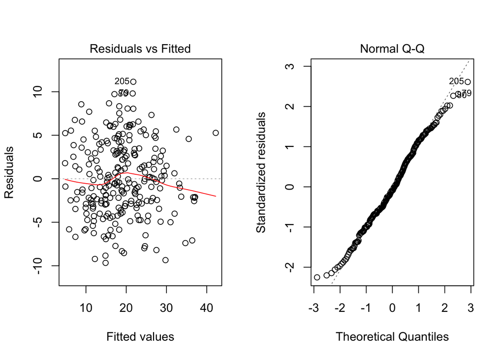

```r
par(mfrow=c(1,2))
plot(bf_step_back,which=1:2) + theme_bw()
```

The QQ plot shows a straight line which indicates that the normality assumption is reasonable. However, the residuals vs fitted plot shows a slight variation; but given that body fat is hard to predict, this is acceptable.

#### 2.1.4 Final fitted model

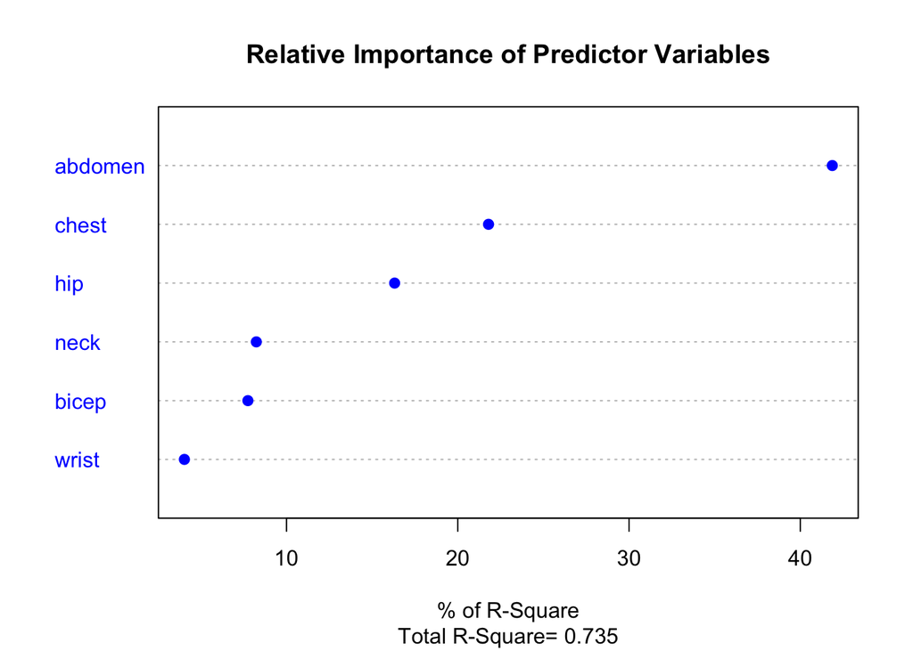

```
##           Weights
## wrist    4.038431
## bicep    7.746760
## neck     8.238378
## hip     16.313788
## chest   21.795458
## abdomen 41.867184
```

```r
relbf <- function(fit,...){
  R <- cor(fit$model)
  nvar <- ncol(R)
  rxx <- R[2:nvar, 2:nvar]
  rxy <- R[2:nvar, 1]
  svd <- eigen(rxx)
  evec <- svd$vectors
  ev <- svd$values
  delta <- diag(sqrt(ev))
  lambda <- evec %*% delta %*% t(evec)
  lambdasq <- lambda ^ 2
  beta <- solve(lambda) %*% rxy
  rsquare <- colSums(beta ^ 2)
  rawwgt <- lambdasq %*% beta ^ 2
  import <- (rawwgt / rsquare) * 100
  import <- as.data.frame(import)
  row.names(import) <- names(fit$model[2:nvar])
  names(import) <- "Weights"
  import <- import[order(import),1, drop=FALSE]
  dotchart(import$Weights, labels=row.names(import),
           xlab="% of R-Square", pch=19,
           main="Relative Importance of Predictor Variables",
           sub=paste("Total R-Square=", round(rsquare, digits=3)),
           ...)
  return(import)
}
relbf(bf_step_back, col="blue")
```

The final model is:

$$\hat{body-fat} = 1.52 -0.3965neck - 0.128chest + 1.01805abdomen -0.28758hip + 0.26bicep -1.55084wrist$$

and abdomen is relatively the most important predictor for predicting body fat percentage.

1. On average, holding the other variables constant, a 1 unit increase in Neck leads to a 0.3965 unit decrease in Body Fat Percentage
2. On average, holding the other variables constant, a 1 unit increase in Chest leads to a 0.128 unit decrease in Body Fat Percentage
3. On average, holding the other variables constant, a 1 unit increase in Abdomen leads to a 1.01805 unit increase in Body Fat Percentage
4. On average, holding the other variables constant, a 1 unit increase in Hip leads to a 0.28758 unit decrease in Body Fat Percentage
5. On average, holding the other variables constant, a 1 unit increase in Bicep leads to a 0.26 unit increase in Body Fat Percentage
6. On average, holding the other variables constant, a 1 unit increase in Wrist leads to a 1.5508 unit decrease in Body Fat Percentage

### 2.2 BMI

For this analysis, the formula of BMI is

$$BMI = \frac{Weight (lbs)*703}{Height(in)^2}$$

#### 2.2.1 Defining the model with population parameters

$$BMI = \beta_0 + \beta_1Neck + \beta_2Chest \\ + \beta_3Abdomen + \beta_4Waist + \beta_5Hip + \beta_6Thigh + \beta_7Knee + \beta_8Ankle \\+ \beta_9Bicep + \beta_{10}Forearm + \beta_{11}Wrist + \epsilon$$

```r
qtlcharts::iplotCorr(data_bmi)
```

[interactive chart not shown]

Based on the interactive correlation matrix, it can be seen the level of correlation differs quite drastically between the variables and the backward variable selection method is also adopted here.

#### 2.2.2 Multiple Regression with Variable Selection

```r
bmi_lm = lm(bmi~.,data=data_bmi)
summary(bmi_lm)
```

```
##
## Call:
## lm(formula = bmi ~ ., data = data_bmi)
##
## Residuals:
##     Min      1Q  Median      3Q     Max
## -3.1790 -0.6548  0.0086  0.6881  3.8335
##
## Coefficients: (1 not defined because of singularities)
##               Estimate Std. Error t value Pr(>|t|)
## (Intercept) -11.938661   1.725613  -6.919 4.19e-11 ***
## age           0.010049   0.007594   1.323   0.1870
## neck          0.031474   0.056108   0.561   0.5754
## chest         0.149956   0.022420   6.688 1.59e-10 ***
## abdomen       0.118223   0.020898   5.657 4.40e-08 ***
## waist               NA         NA      NA       NA
## hip           0.060113   0.032231   1.865   0.0634 .
## thigh         0.151883   0.034888   4.353 1.99e-05 ***
## knee         -0.265374   0.056116  -4.729 3.87e-06 ***
## ankle         0.067577   0.053692   1.259   0.2094
## bicep         0.049712   0.041497   1.198   0.2321
## forearm       0.086789   0.051015   1.701   0.0902 .
## wrist        -0.045825   0.129082  -0.355   0.7229
## ---
## Signif. codes:  0 '***' 0.001 '**' 0.01 '*' 0.05 '.' 0.1 ' ' 1
##
## Residual standard error: 1.058 on 238 degrees of freedom
## Multiple R-squared:  0.9046, Adjusted R-squared:  0.9002
## F-statistic: 205.1 on 11 and 238 DF,  p-value: < 2.2e-16
```

```r
bmi_step_back = step(bmi_lm, direction = "backward",trace = FALSE)
summary(bmi_step_back)
```

```
##
## Call:
## lm(formula = bmi ~ chest + abdomen + hip + thigh + knee + forearm,
##     data = data_bmi)
##
## Residuals:
##     Min      1Q  Median      3Q     Max
## -3.1197 -0.6944 -0.0274  0.6831  3.8464
##
## Coefficients:
##              Estimate Std. Error t value Pr(>|t|)
## (Intercept) -10.94257    1.43829  -7.608 6.10e-13 ***
## chest         0.16090    0.02122   7.582 7.18e-13 ***
## abdomen       0.12726    0.01826   6.968 3.01e-11 ***
## hip           0.05047    0.03084   1.637   0.1030
## thigh         0.14983    0.03032   4.942 1.44e-06 ***
## knee         -0.23116    0.05148  -4.490 1.10e-05 ***
## forearm       0.11484    0.04468   2.571   0.0108 *
## ---
## Signif. codes:  0 '***' 0.001 '**' 0.01 '*' 0.05 '.' 0.1 ' ' 1
##
## Residual standard error: 1.058 on 243 degrees of freedom
## Multiple R-squared:  0.9024, Adjusted R-squared:    0.9
## F-statistic: 374.6 on 6 and 243 DF,  p-value: < 2.2e-16
```

Based on the backward selection model, the fitted model has become:

$$\hat{BMI} = -10.94 +0.161Chest + 0.127Abdomen + 0.050Hip + 0.150 Thigh - 0.23Knee + 0.115Forearm$$

#### 2.2.3 Check Assumptions

Finally, to check assumption, we perform the ggfortify function.

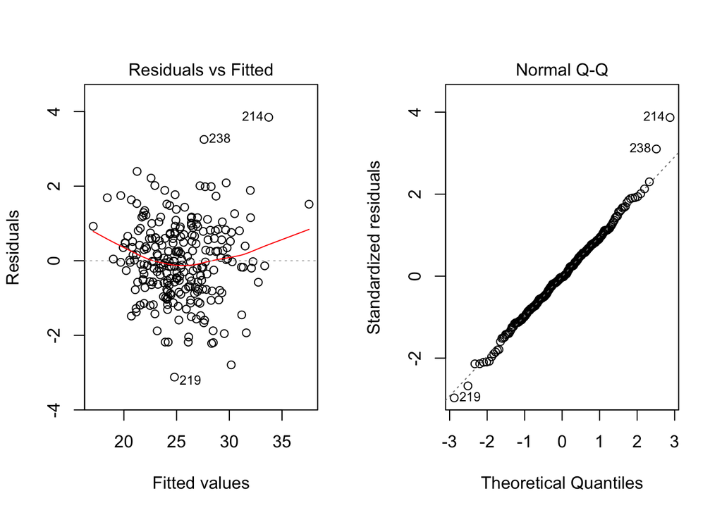

```r
par(mfrow=c(1,2))
plot(bmi_step_back,which=1:2) + theme_bw()
```

The QQ plot shows a straight line which indicates that the normality assumption is reasonable. However, the residuals vs fitted plot shows a fan shaped plot which indicates that the assumption of homogeneous variance is violated. We can use a log transformed response and re-fit the linear regression.

```r
ln_bmi_lm = lm(log(bmi)~.,data=data_bmi)
summary(ln_bmi_lm)
```

```
##
## Call:
## lm(formula = log(bmi) ~ ., data = data_bmi)
##
## Residuals:
##       Min        1Q    Median        3Q       Max
## -0.133137 -0.024215 -0.000443  0.027919  0.102670
##
## Coefficients: (1 not defined because of singularities)
##               Estimate Std. Error t value Pr(>|t|)
## (Intercept)  1.7512060  0.0654240  26.767  < 2e-16 ***
## age          0.0005158  0.0002879   1.791 0.074515 .
## neck         0.0017502  0.0021272   0.823 0.411459
## chest        0.0055041  0.0008500   6.475 5.37e-10 ***
## abdomen      0.0044728  0.0007923   5.645 4.68e-08 ***
## waist               NA         NA      NA       NA
## hip          0.0010150  0.0012220   0.831 0.407026
## thigh        0.0069490  0.0013227   5.253 3.31e-07 ***
## knee        -0.0082150  0.0021276  -3.861 0.000145 ***
## ankle        0.0026638  0.0020357   1.309 0.191940
## bicep        0.0024437  0.0015733   1.553 0.121689
## forearm      0.0038084  0.0019341   1.969 0.050112 .
## wrist       -0.0017188  0.0048940  -0.351 0.725745
## ---
## Signif. codes:  0 '***' 0.001 '**' 0.01 '*' 0.05 '.' 0.1 ' ' 1
##
## Residual standard error: 0.04009 on 238 degrees of freedom
## Multiple R-squared:  0.9079, Adjusted R-squared:  0.9036
## F-statistic: 213.2 on 11 and 238 DF,  p-value: < 2.2e-16
```

```r
ln_bmi_step_back = step(ln_bmi_lm, direction = "backward",trace = FALSE)
summary(ln_bmi_step_back)
```

```
##
## Call:
## lm(formula = log(bmi) ~ age + chest + abdomen + thigh + knee +
##     bicep + forearm, data = data_bmi)
##
## Residuals:
##       Min        1Q    Median        3Q       Max
## -0.132191 -0.023020 -0.000321  0.027716  0.106640
##
## Coefficients:
##               Estimate Std. Error t value Pr(>|t|)
## (Intercept)  1.7989069  0.0524420  34.303  < 2e-16 ***
## age          0.0004265  0.0002629   1.622 0.106083
## chest        0.0058017  0.0008196   7.079 1.57e-11 ***
## abdomen      0.0047155  0.0007078   6.662 1.80e-10 ***
## thigh        0.0075055  0.0011966   6.273 1.62e-09 ***
## knee        -0.0069254  0.0018984  -3.648 0.000324 ***
## bicep        0.0026331  0.0015455   1.704 0.089720 .
## forearm      0.0042579  0.0018372   2.318 0.021306 *
## ---
## Signif. codes:  0 '***' 0.001 '**' 0.01 '*' 0.05 '.' 0.1 ' ' 1
##
## Residual standard error: 0.04002 on 242 degrees of freedom
## Multiple R-squared:  0.9067, Adjusted R-squared:  0.904
## F-statistic: 335.8 on 7 and 242 DF,  p-value: < 2.2e-16
```

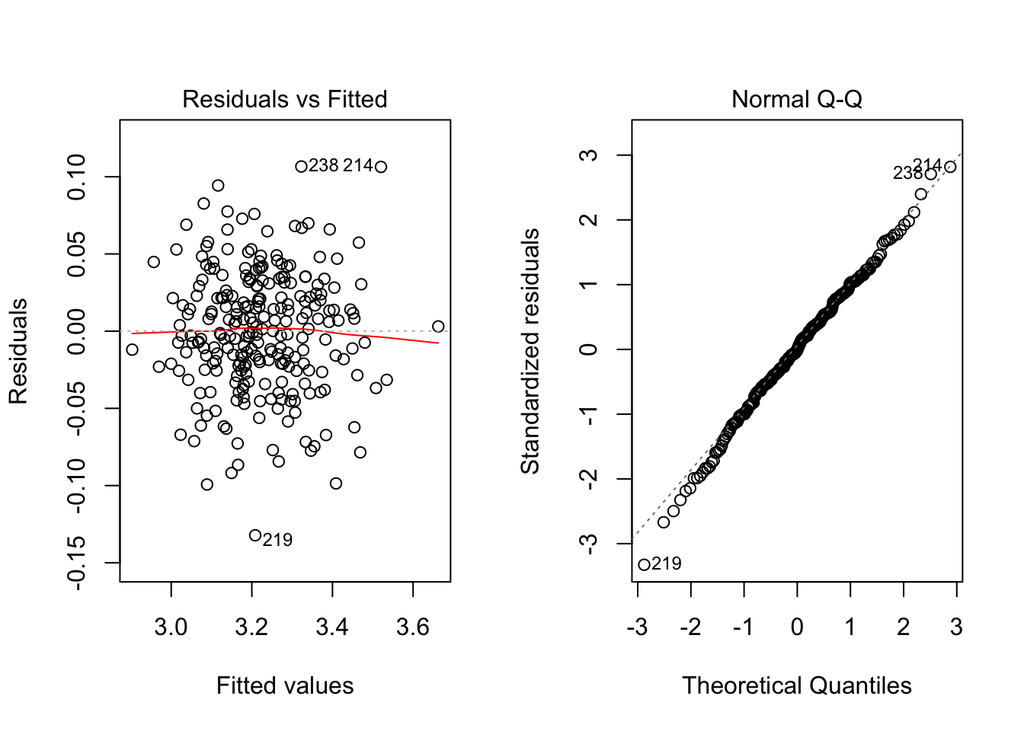

```r
par(mfrow=c(1,2))
plot(ln_bmi_step_back,which=1:2) + theme_bw()
```

```r
sjPlot::tab_model(bmi_step_back, ln_bmi_step_back, digits = 5, show.ci = FALSE)
```

|  | bmi |  | log(bmi) |  |
| --- | --- | --- | --- | --- |
| Predictors | Estimates | p | Estimates | p |
| (Intercept) | -10.94257 | **<0.001** | 1.79891 | **<0.001** |
| chest | 0.16090 | **<0.001** | 0.00580 | **<0.001** |
| abdomen | 0.12726 | **<0.001** | 0.00472 | **<0.001** |
| hip | 0.05047 | 0.103 |  |  |
| thigh | 0.14983 | **<0.001** | 0.00751 | **<0.001** |
| knee | -0.23116 | **<0.001** | -0.00693 | **<0.001** |
| forearm | 0.11484 | **0.011** | 0.00426 | **0.021** |
| age |  |  | 0.00043 | 0.106 |
| bicep |  |  | 0.00263 | 0.090 |
| Observations | 250 |  | 250 |  |
| R<sup>2</sup> / R<sup>2</sup> adjusted | 0.902 / 0.900 |  | 0.907 / 0.904 |  |

However, although the transformation has aided with the homogeneous variance assumption, the interpretation itself does not make much sense - BMI is determined by an increase in value, not the increase in percentage change. Hence in the final comparison, we will use the untransformed model.

#### 2.2.4 Final Fitted Model

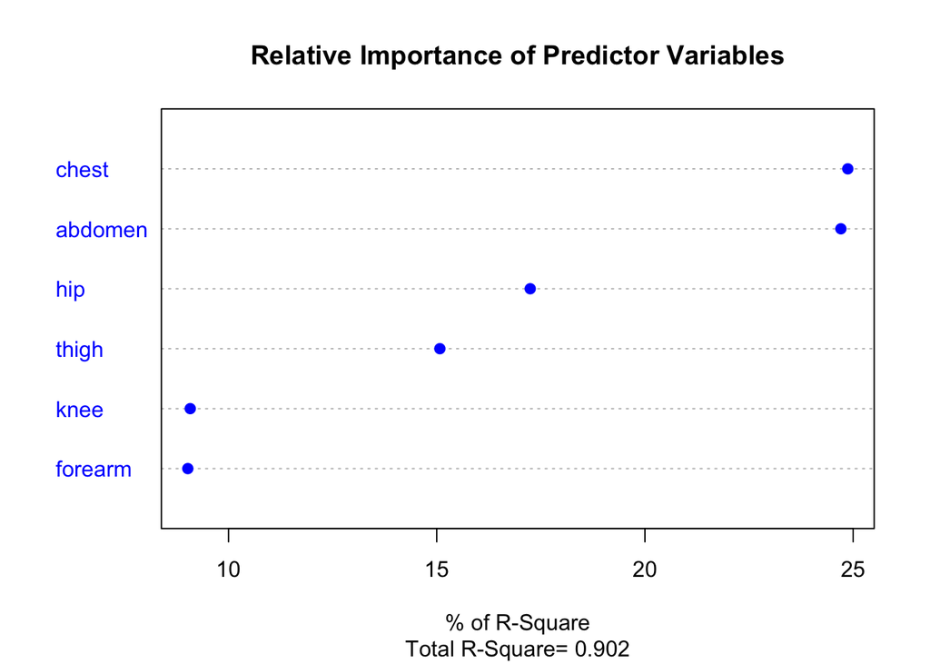

```
##           Weights
## forearm  9.021850
## knee     9.080285
## thigh   15.075099
## hip     17.245099
## abdomen 24.705834
## chest   24.871833
```

```r
relbmi <- function(fit,...){
  R <- cor(fit$model)
  nvar <- ncol(R)
  rxx <- R[2:nvar, 2:nvar]
  rxy <- R[2:nvar, 1]
  svd <- eigen(rxx)
  evec <- svd$vectors
  ev <- svd$values
  delta <- diag(sqrt(ev))
  lambda <- evec %*% delta %*% t(evec)
  lambdasq <- lambda ^ 2
  beta <- solve(lambda) %*% rxy
  rsquare <- colSums(beta ^ 2)
  rawwgt <- lambdasq %*% beta ^ 2
  import <- (rawwgt / rsquare) * 100
  import <- as.data.frame(import)
  row.names(import) <- names(fit$model[2:nvar])
  names(import) <- "Weights"
  import <- import[order(import),1, drop=FALSE]
  dotchart(import$Weights, labels=row.names(import),
           xlab="% of R-Square", pch=19,
           main="Relative Importance of Predictor Variables",
           sub=paste("Total R-Square=", round(rsquare, digits=3)),
           ...)
  return(import)
}
relbmi(bmi_step_back, col="blue")
```

The final model is:

$$\hat{BMI} = -10.94 +0.161Chest + 0.127Abdomen + 0.050Hip + 0.150 Thigh - 0.23Knee + 0.115Forearm$$
and both chest and abdomen are relatively more important in predicting BMI.

### 2.3 Body Density

#### 2.3.1 Defining the model with population parameters

$$Body Density = \beta_0 + \beta_1Pcf.BF + \beta_2Age + \beta_3Weight + \beta_4Height\\
+ \beta_5Neck + \beta_6Chest + \beta_7Abdomen + \beta_8Waist + \beta_9Hip + \beta_{10}Thigh\\ + \beta_{11}Knee + \beta_{12}Ankle + \beta_{13}Bicep + \beta_{14}Forearm + \beta_{15}Wrist + \epsilon$$

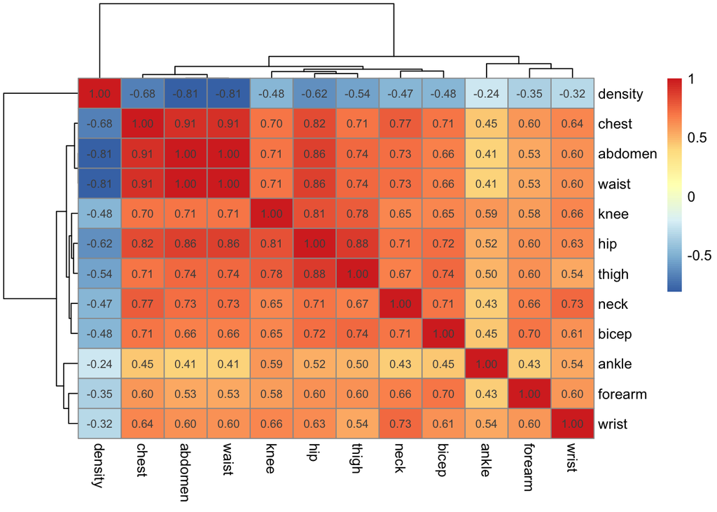

```r
cor_matrix <- cor(data_density)
pheatmap(cor_matrix, display_numbers = T,na.rm=T)
```

#### 2.3.2 Check Assumptions

The residuals $\epsilon_i$ are iid $N(0,\sigma^2)$ and there is a linear relationship between y and x.

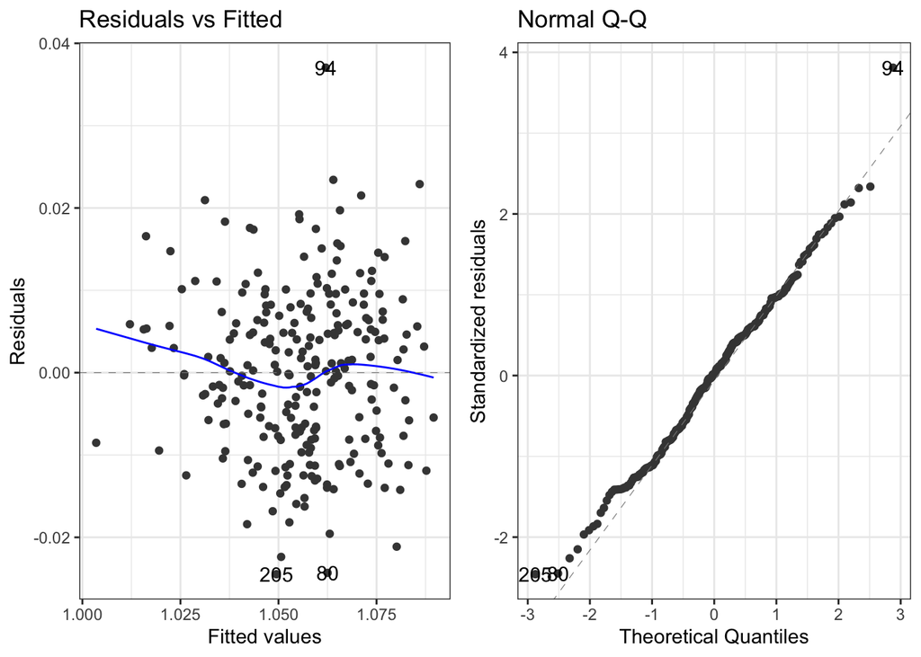

```r
M0 <- lm(density ~ 1, data = data_density)  # Null model
M1 <- lm(density ~ ., data = data_density)  # Full model
autoplot(M1,which=1:2)+theme_bw()
```

```r
round(summary(M1)$coef, 3)
```

```
##             Estimate Std. Error t value Pr(>|t|)
## (Intercept)    1.082      0.016  68.068    0.000
## neck           0.001      0.001   2.074    0.039
## chest          0.000      0.000   1.818    0.070
## abdomen       -0.002      0.000 -13.645    0.000
## hip            0.001      0.000   2.950    0.003
## thigh          0.000      0.000  -0.980    0.328
## knee           0.000      0.001   0.689    0.492
## ankle          0.000      0.001  -0.675    0.500
## bicep         -0.001      0.000  -1.357    0.176
## forearm        0.000      0.000  -0.947    0.345
## wrist          0.004      0.001   3.310    0.001
```

```r
step.fwd.aic <- step(M0, scope = list(lower = M0, upper = M1), direction = "forward", trace = FALSE)
summary(step.fwd.aic)
```

```
##
## Call:
## lm(formula = density ~ waist + wrist + hip + chest + bicep +
##     neck, data = data_density)
##
## Residuals:
##       Min        1Q    Median        3Q       Max
## -0.024142 -0.007680  0.000523  0.006156  0.038390
##
## Coefficients:
##               Estimate Std. Error t value Pr(>|t|)
## (Intercept)  1.0844660  0.0154768  70.070  < 2e-16 ***
## waist       -0.0060402  0.0004401 -13.724  < 2e-16 ***
## wrist        0.0038812  0.0010612   3.657 0.000312 ***
## hip          0.0006990  0.0002153   3.247 0.001331 **
## chest        0.0003881  0.0002097   1.851 0.065427 .
## bicep       -0.0007779  0.0003535  -2.201 0.028695 *
## neck         0.0009609  0.0005185   1.853 0.065030 .
## ---
## Signif. codes:  0 '***' 0.001 '**' 0.01 '*' 0.05 '.' 0.1 ' ' 1
##
## Residual standard error: 0.01007 on 243 degrees of freedom
## Multiple R-squared:  0.722,  Adjusted R-squared:  0.7152
## F-statistic: 105.2 on 6 and 243 DF,  p-value: < 2.2e-16
```

```r
step.back.aic <- step(M1, scope = list(lower = M0, upper = M1), direction = "backward", trace = FALSE)
summary(step.back.aic)
```

```
##
## Call:
## lm(formula = density ~ neck + chest + abdomen + hip + bicep +
##     wrist, data = data_density)
##
## Residuals:
##       Min        1Q    Median        3Q       Max
## -0.024142 -0.007680  0.000523  0.006156  0.038390
##
## Coefficients:
##               Estimate Std. Error t value Pr(>|t|)
## (Intercept)  1.0844660  0.0154768  70.070  < 2e-16 ***
## neck         0.0009609  0.0005185   1.853 0.065030 .
## chest        0.0003881  0.0002097   1.851 0.065428 .
## abdomen     -0.0023780  0.0001733 -13.724  < 2e-16 ***
## hip          0.0006990  0.0002153   3.247 0.001331 **
## bicep       -0.0007779  0.0003535  -2.201 0.028694 *
## wrist        0.0038812  0.0010612   3.657 0.000312 ***
## ---
## Signif. codes:  0 '***' 0.001 '**' 0.01 '*' 0.05 '.' 0.1 ' ' 1
##
## Residual standard error: 0.01007 on 243 degrees of freedom
## Multiple R-squared:  0.722,  Adjusted R-squared:  0.7152
## F-statistic: 105.2 on 6 and 243 DF,  p-value: < 2.2e-16
```

```r
exh <- regsubsets(density~., data = data_density, nvmax = 15)
```

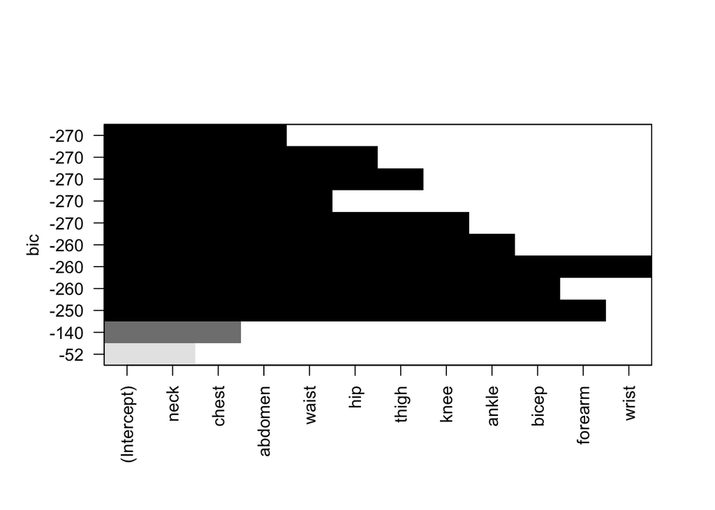

```r
plot(exh,scale="bic")
```

#### 2.3.3 Multiple Regression using the BIC

```r
M2<- lm(formula = density ~ neck + chest + abdomen,
    data = data_density)
summary(M2)
```

```
##
## Call:
## lm(formula = density ~ neck + chest + abdomen, data = data_density)
##
## Residuals:
##       Min        1Q    Median        3Q       Max
## -0.029395 -0.007156 -0.000682  0.007305  0.046687
##
## Coefficients:
##               Estimate Std. Error t value Pr(>|t|)
## (Intercept)  1.1392164  0.0119499  95.333  < 2e-16 ***
## neck         0.0017212  0.0004599   3.743 0.000226 ***
## chest        0.0004569  0.0002135   2.140 0.033361 *
## abdomen     -0.0021095  0.0001592 -13.250  < 2e-16 ***
## ---
## Signif. codes:  0 '***' 0.001 '**' 0.01 '*' 0.05 '.' 0.1 ' ' 1
##
## Residual standard error: 0.01057 on 246 degrees of freedom
## Multiple R-squared:  0.6904, Adjusted R-squared:  0.6867
## F-statistic: 182.9 on 3 and 246 DF,  p-value: < 2.2e-16
```

```r
M3<- lm(formula = density ~ neck + chest + abdomen + waist ,
    data = data_density)
summary(M3)
```

```
##
## Call:
## lm(formula = density ~ neck + chest + abdomen + waist, data = data_density)
##
## Residuals:
##       Min        1Q    Median        3Q       Max
## -0.029395 -0.007156 -0.000682  0.007305  0.046687
##
## Coefficients: (1 not defined because of singularities)
##               Estimate Std. Error t value Pr(>|t|)
## (Intercept)  1.1392164  0.0119499  95.333  < 2e-16 ***
## neck         0.0017212  0.0004599   3.743 0.000226 ***
## chest        0.0004569  0.0002135   2.140 0.033361 *
## abdomen     -0.0021095  0.0001592 -13.250  < 2e-16 ***
## waist               NA         NA      NA       NA
## ---
## Signif. codes:  0 '***' 0.001 '**' 0.01 '*' 0.05 '.' 0.1 ' ' 1
##
## Residual standard error: 0.01057 on 246 degrees of freedom
## Multiple R-squared:  0.6904, Adjusted R-squared:  0.6867
## F-statistic: 182.9 on 3 and 246 DF,  p-value: < 2.2e-16
```

Drop waist and add other variables

```r
M4<- lm(formula = density ~ neck + chest + abdomen + hip ,
    data = data_density)
summary(M4)
```

```
##
## Call:
## lm(formula = density ~ neck + chest + abdomen + hip, data = data_density)
##
## Residuals:
##       Min        1Q    Median        3Q       Max
## -0.028989 -0.007256  0.000047  0.006767  0.045116
##
## Coefficients:
##               Estimate Std. Error t value Pr(>|t|)
## (Intercept)  1.1150223  0.0139695  79.818  < 2e-16 ***
## neck         0.0014682  0.0004584   3.203  0.00154 **
## chest        0.0003734  0.0002113   1.768  0.07837 .
## abdomen     -0.0023671  0.0001759 -13.455  < 2e-16 ***
## hip          0.0006619  0.0002074   3.191  0.00160 **
## ---
## Signif. codes:  0 '***' 0.001 '**' 0.01 '*' 0.05 '.' 0.1 ' ' 1
##
## Residual standard error: 0.01037 on 245 degrees of freedom
## Multiple R-squared:  0.7028, Adjusted R-squared:  0.6979
## F-statistic: 144.8 on 4 and 245 DF,  p-value: < 2.2e-16
```

```r
M5<- lm(formula = density ~ neck + chest + abdomen + hip + thigh ,
    data = data_density)
summary(M5)
```

```
##
## Call:
## lm(formula = density ~ neck + chest + abdomen + hip + thigh,
##     data = data_density)
##
## Residuals:
##       Min        1Q    Median        3Q       Max
## -0.029545 -0.006988  0.000516  0.007098  0.043367
##
## Coefficients:
##               Estimate Std. Error t value Pr(>|t|)
## (Intercept)  1.1073577  0.0144127  76.832  < 2e-16 ***
## neck         0.0016460  0.0004644   3.544 0.000472 ***
## chest        0.0003393  0.0002107   1.610 0.108626
## abdomen     -0.0023869  0.0001752 -13.627  < 2e-16 ***
## hip          0.0010639  0.0002889   3.682 0.000285 ***
## thigh       -0.0005716  0.0002878  -1.986 0.048171 *
## ---
## Signif. codes:  0 '***' 0.001 '**' 0.01 '*' 0.05 '.' 0.1 ' ' 1
##
## Residual standard error: 0.01031 on 244 degrees of freedom
## Multiple R-squared:  0.7075, Adjusted R-squared:  0.7015
## F-statistic:   118 on 5 and 244 DF,  p-value: < 2.2e-16
```

Drop chest and add other variables

```r
M6<- lm(formula = density ~ neck + abdomen + hip + thigh + knee ,
    data = data_density)
summary(M6)
```

```
##
## Call:
## lm(formula = density ~ neck + abdomen + hip + thigh + knee, data = data_density)
##
## Residuals:
##       Min        1Q    Median        3Q       Max
## -0.029361 -0.007760  0.000360  0.007152  0.043816
##
## Coefficients:
##               Estimate Std. Error t value Pr(>|t|)
## (Intercept)  1.1035095  0.0150104  73.517  < 2e-16 ***
## neck         0.0018149  0.0004395   4.129    5e-05 ***
## abdomen     -0.0022098  0.0001347 -16.402  < 2e-16 ***
## hip          0.0010035  0.0002984   3.363 0.000894 ***
## thigh       -0.0007038  0.0002938  -2.395 0.017355 *
## knee         0.0007551  0.0005006   1.508 0.132778
## ---
## Signif. codes:  0 '***' 0.001 '**' 0.01 '*' 0.05 '.' 0.1 ' ' 1
##
## Residual standard error: 0.01032 on 244 degrees of freedom
## Multiple R-squared:  0.7071, Adjusted R-squared:  0.7011
## F-statistic: 117.8 on 5 and 244 DF,  p-value: < 2.2e-16
```

Drop knee

```r
M7<- lm(formula = density ~ neck + abdomen + hip + thigh ,
    data = data_density)
summary(M7)
```

```
##
## Call:
## lm(formula = density ~ neck + abdomen + hip + thigh, data = data_density)
##
## Residuals:
##       Min        1Q    Median        3Q       Max
## -0.030204 -0.007301  0.000653  0.007199  0.045107
##
## Coefficients:
##               Estimate Std. Error t value Pr(>|t|)
## (Intercept)  1.1104052  0.0143343  77.465  < 2e-16 ***
## neck         0.0019085  0.0004362   4.375  1.8e-05 ***
## abdomen     -0.0022064  0.0001351 -16.337  < 2e-16 ***
## hip          0.0011314  0.0002868   3.945 0.000104 ***
## thigh       -0.0006094  0.0002878  -2.117 0.035236 *
## ---
## Signif. codes:  0 '***' 0.001 '**' 0.01 '*' 0.05 '.' 0.1 ' ' 1
##
## Residual standard error: 0.01035 on 245 degrees of freedom
## Multiple R-squared:  0.7044, Adjusted R-squared:  0.6996
## F-statistic:   146 on 4 and 245 DF,  p-value: < 2.2e-16
```

#### 2.3.4 Final Fitted Model

[figure not shown]

```
##           Weights
## forearm  9.021850
## knee     9.080285
## thigh   15.075099
## hip     17.245099
## abdomen 24.705834
## chest   24.871833
```

```r
relweights <- function(fit,...){
  R <- cor(fit$model)
  nvar <- ncol(R)
  rxx <- R[2:nvar, 2:nvar]
  rxy <- R[2:nvar, 1]
  svd <- eigen(rxx)
  evec <- svd$vectors
  ev <- svd$values
  delta <- diag(sqrt(ev))
  lambda <- evec %*% delta %*% t(evec)
  lambdasq <- lambda ^ 2
  beta <- solve(lambda) %*% rxy
  rsquare <- colSums(beta ^ 2)
  rawwgt <- lambdasq %*% beta ^ 2
  import <- (rawwgt / rsquare) * 100
  import <- as.data.frame(import)
  row.names(import) <- names(fit$model[2:nvar])
  names(import) <- "Weights"
  import <- import[order(import),1, drop=FALSE]
  dotchart(import$Weights, labels=row.names(import),
           xlab="% of R-Square", pch=19,
           main="Relative Importance of Predictor Variables",
           sub=paste("Total R-Square=", round(rsquare, digits=3)),
           ...)
  return(import)
}
relweights(bmi_step_back, col="blue")
```

1. On average, holding the other variables constant, a 1% increase in Neck leads to a 0.2% unit increase in Density
2. On average, holding the other variables constant, a 1% increase in Abdomen leads to a 0.2% decrease in Density
3. On average, holding the other variables constant, a 1% increase in Hip leads to a 0.1% increase in Density
4. On average, holding the other variables constant, a 1% increase in Thigh leads to a 0.06% decrease in Density

#### 2.3.5 Linear regression assumptions for the stepwise model

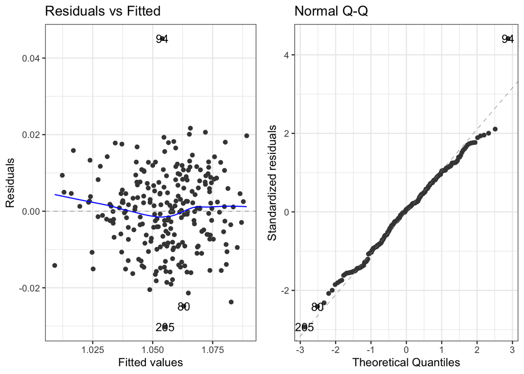

```r
autoplot(M7,which=1:2)+theme_bw()
```

### 2.4 Predict Overweight

#### Which variables can best predict whether a person is overweight?

Since the variable ‘Overweight’ is dichotomous (binary), we perform a logistic regression to interpret the relationship between overweight and other significant variables.

#### 2.4.1 Checking for Significance in a Binary Logistic Regression

```r
data_overweight = data[-c(4:5,17)]
data_overweight$overweight = as.numeric(data_overweight$overweight)
glm1 = glm(overweight ~ ., data = data_overweight)
# drop knee
glm2 = glm(overweight ~ density + pct_bf + age + neck + chest + abdomen + waist + hip + thigh + ankle + bicep + forearm + wrist, data = data_overweight)
# drop ankle
glm3 = glm(overweight ~ density + pct_bf + age + neck + chest + abdomen + waist + hip + thigh + bicep + forearm + wrist, data = data_overweight)
# drop density
glm4 = glm(overweight ~ pct_bf + age + neck + chest + abdomen + waist + hip + thigh + bicep + forearm + wrist, data = data_overweight)
# drop age
glm5 = glm(overweight ~ pct_bf + neck + chest + abdomen + waist + hip + thigh + bicep + forearm + wrist, data = data_overweight)
# drop waist
glm6 = glm(overweight ~ pct_bf + neck + chest + abdomen + hip + thigh + bicep + forearm + wrist, data = data_overweight)
```

```r
data_overweight = data[-c(4:5,17)]
data_overweight$overweight = as.numeric(data_overweight$overweight)
glm1 = glm(overweight ~ ., data = data_overweight)
# drop knee
glm2 = glm(overweight ~ density + pct_bf + age + neck + chest + abdomen + waist + hip + thigh + ankle + bicep + forearm + wrist, data = data_overweight)
# drop ankle
glm3 = glm(overweight ~ density + pct_bf + age + neck + chest + abdomen + waist + hip + thigh + bicep + forearm + wrist, data = data_overweight)
# drop density
glm4 = glm(overweight ~ pct_bf + age + neck + chest + abdomen + waist + hip + thigh + bicep + forearm + wrist, data = data_overweight)
# drop age
glm5 = glm(overweight ~ pct_bf + neck + chest + abdomen + waist + hip + thigh + bicep + forearm + wrist, data = data_overweight)
# drop waist
glm6 = glm(overweight ~ pct_bf + neck + chest + abdomen + hip + thigh + bicep + forearm + wrist, data = data_overweight)

glm1 = glm(overweight ~ ., family = binomial, data = data_overweight)
# drop hip
glm2 = glm(overweight ~ density + pct_bf + age + neck + chest + abdomen + waist + knee + thigh + ankle + bicep + forearm + wrist, family = binomial, data = data_overweight)

# drop neck
glm3 = glm(overweight ~ density + pct_bf + age + chest + abdomen + waist + knee + thigh + ankle + bicep + forearm + wrist, family = binomial, data = data_overweight)
# drop forearm
glm4 = glm(overweight ~ density + pct_bf + age + chest + abdomen + waist + knee + thigh + ankle + bicep + wrist, family = binomial, data = data_overweight)
# drop pct_bf
glm5 = glm(overweight ~ density + age + chest + abdomen + waist + knee + thigh + ankle + bicep + wrist, family = binomial, data = data_overweight)
# drop wrist
glm6 = glm(overweight ~ density + age + chest + abdomen + waist + knee + thigh + ankle + bicep, family = binomial, data = data_overweight)
# drop age
glm7 = glm(overweight ~ density + chest + abdomen + waist + knee + thigh + ankle + bicep, family = binomial, data = data_overweight)
# drop knee
glm8 = glm(overweight ~ density + chest + abdomen + waist + thigh + ankle + bicep, family = binomial, data = data_overweight)
# drop ankle
glm9 = glm(overweight ~ density + chest + abdomen + waist + thigh + bicep, family = binomial, data = data_overweight)
# drop waist
glm10 = glm(overweight ~ density + chest + abdomen + thigh + bicep, family = binomial, data = data_overweight)
# drop density
glm11 = glm(overweight ~ chest + abdomen + thigh + bicep, family = binomial, data = data_overweight)
# drop bicep
glm12 = glm(overweight ~ chest + abdomen + thigh, family = binomial, data = data_overweight)
summary(glm12)
```

```
##
## Call:
## glm(formula = overweight ~ chest + abdomen + thigh, family = binomial,
##     data = data_overweight)
##
## Deviance Residuals:
##      Min        1Q    Median        3Q       Max
## -2.37220  -0.17575  -0.00018   0.15018   2.29089
##
## Coefficients:
##              Estimate Std. Error z value Pr(>|z|)
## (Intercept) -75.89380   11.89377  -6.381 1.76e-10 ***
## chest         0.37854    0.09686   3.908 9.30e-05 ***
## abdomen       0.27128    0.07243   3.746  0.00018 ***
## thigh         0.22381    0.09638   2.322  0.02022 *
## ---
## Signif. codes:  0 '***' 0.001 '**' 0.01 '*' 0.05 '.' 0.1 ' ' 1
##
## (Dispersion parameter for binomial family taken to be 1)
##
##     Null deviance: 346.574  on 249  degrees of freedom
## Residual deviance:  98.505  on 246  degrees of freedom
## AIC: 106.5
##
## Number of Fisher Scoring iterations: 8
```

Before we start making predictions with the model, we drop the variables which are not a significant predictor for being overweight. The fitted model is shown below.

#### 2.4.2 Fitted Model (log odds scale)

$$logit(p) = log(\frac{p}{1-p}) = -75.89380 + 0.37854Chest\\
+ 0.27128Abdomen + 0.22381Thigh\\$$
where the logit(p) is a special link from our linear combination of predictors to the probability of the outcome being equal to 1, and the coefficients are interpreted as changes in log-odds.

#### 2.4.3 Visualising Coefficients (odds scale) and Predictions

```r
summary(glm12)
```

```
##
## Call:
## glm(formula = overweight ~ chest + abdomen + thigh, family = binomial,
##     data = data_overweight)
##
## Deviance Residuals:
##      Min        1Q    Median        3Q       Max
## -2.37220  -0.17575  -0.00018   0.15018   2.29089
##
## Coefficients:
##              Estimate Std. Error z value Pr(>|z|)
## (Intercept) -75.89380   11.89377  -6.381 1.76e-10 ***
## chest         0.37854    0.09686   3.908 9.30e-05 ***
## abdomen       0.27128    0.07243   3.746  0.00018 ***
## thigh         0.22381    0.09638   2.322  0.02022 *
## ---
## Signif. codes:  0 '***' 0.001 '**' 0.01 '*' 0.05 '.' 0.1 ' ' 1
##
## (Dispersion parameter for binomial family taken to be 1)
##
##     Null deviance: 346.574  on 249  degrees of freedom
## Residual deviance:  98.505  on 246  degrees of freedom
## AIC: 106.5
##
## Number of Fisher Scoring iterations: 8
```

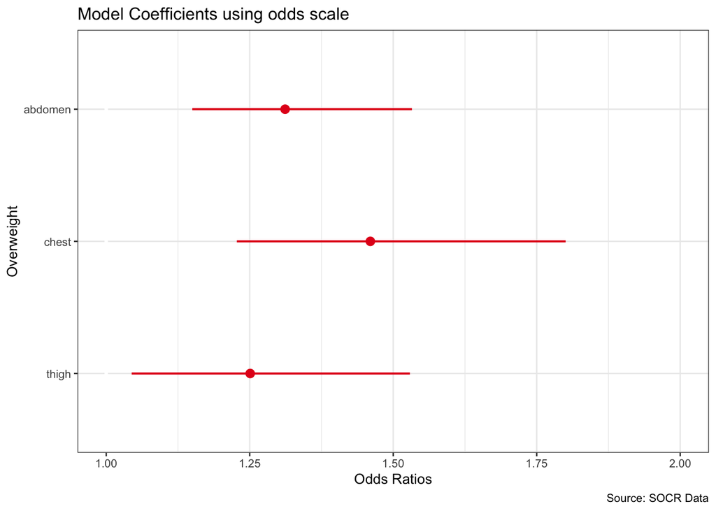

```r
#tab_model(glm0, transform = NULL)
plot_model(glm12) + theme_bw(base_size = 10) + ylim(1, 2) + labs(x = "Overweight", y = "Odds Ratios", title = "Model Coefficients using odds scale",caption='Source: SOCR Data')
```

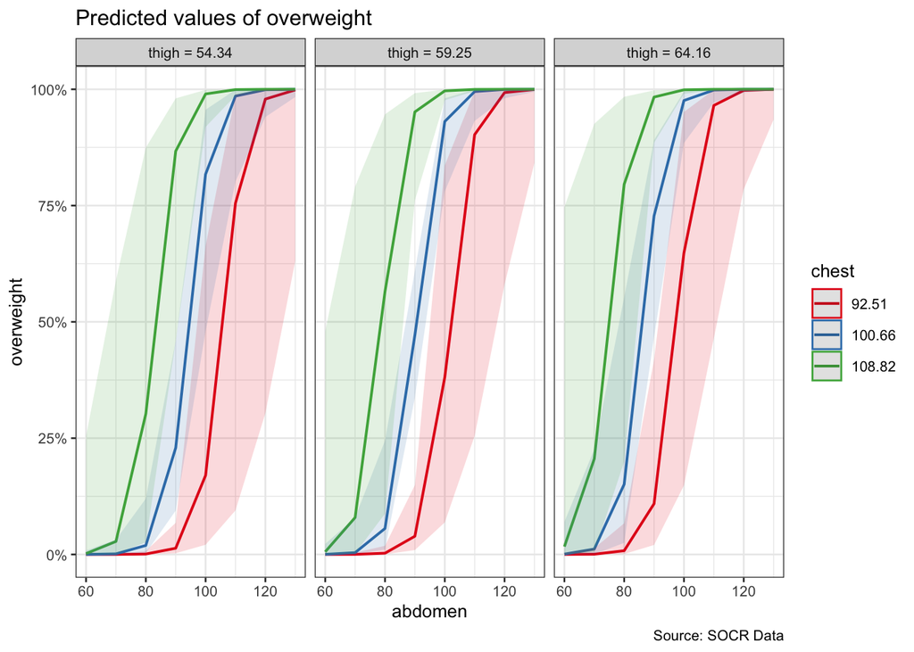

```r
plot_model(glm12, type = "pred", terms = c("abdomen", "chest", "thigh"), show.data = TRUE) + theme_bw(base_size = 10) + labs(caption='Source: SOCR Data')
```

In the Coefficient graph, the three significant variables have similar odd ratios giving the model a smaller confidence interval.

#### 2.4.4 Evaluating (in-sample) performance

```r
glm0 = glm(overweight ~ chest + abdomen + bicep, family = binomial, data = data)
data = data %>%
  mutate(pred_prob = predict(glm0, type = "response"),
         pred_surv = round(pred_prob))
mean(data$overweight == data$pred_surv)
```

```
## [1] 0.932
```

```r
table(data$pred_surv)
```

```
##
##   0   1
## 128 122
```

```r
confusion.glm = confusionMatrix(
  data = as.factor(data$pred_surv),
  reference = as.factor(data$overweight))
confusion.glm$table
```

```
##           Reference
## Prediction   0   1
##          0 118  10
##          1   7 115
```

```r
confusion.glm
```

```
## Confusion Matrix and Statistics
##
##           Reference
## Prediction   0   1
##          0 118  10
##          1   7 115
##
##                Accuracy : 0.932
##                  95% CI : (0.8934, 0.9599)
##     No Information Rate : 0.5
##     P-Value [Acc > NIR] : <2e-16
##
##                   Kappa : 0.864
##
##  Mcnemar's Test P-Value : 0.6276
##
##             Sensitivity : 0.9440
##             Specificity : 0.9200
##          Pos Pred Value : 0.9219
##          Neg Pred Value : 0.9426
##              Prevalence : 0.5000
##          Detection Rate : 0.4720
##    Detection Prevalence : 0.5120
##       Balanced Accuracy : 0.9320
##
##        'Positive' Class : 0
##
```

```r
predict_overweight = data.frame(abdomen = 110, chest = mean(data$chest), thigh = mean(data$thigh))
predict(glm12, newdata = predict_overweight, type = "link")
```

```
##        1
## 5.312144
```

```r
predict_overweight = data.frame(abdomen = 65, chest = mean(data$chest), thigh = mean(data$thigh))
predict(glm12, newdata = predict_overweight, type = "link")
```

```
##         1
## -6.895542
```

```r
data_overweight$overweight=as.character(data_overweight$overweight)
data$pred_surv= as.factor(data$pred_surv)
data$overweight = as.factor(data$overweight)
library(caret)
confusion.glm = confusionMatrix(data = data$pred_surv, reference = data$overweight)
confusion.glm$table
```

```
##           Reference
## Prediction   0   1
##          0 118  10
##          1   7 115
```

```r
library(partykit)
library(rpart)
data_overweight$overweight=as.character(data_overweight$overweight)
```

```r
ov_tree = rpart(overweight ~ abdomen + chest + bicep, data = data_overweight, method = "class",control = rpart.control(cp = 0.009))
predict_overweight = data.frame(abdomen = mean(data$abdomen)*1.1, chest = mean(data$chest)*1.1, thigh = mean(data$thigh)*1.1)
predict(glm12, newdata = predict_overweight, type = "link")
```

```
##        1
## 8.146941
```

#### 2.4.5 Decision Tree

```r
data$overweight=as.character(data$overweight)
ov_tree = rpart(overweight ~ abdomen + chest + thigh, data = data, method = "class",control = rpart.control(cp = 0.008))
ov_tree
```

```
## n= 250
##
## node), split, n, loss, yval, (yprob)
##       * denotes terminal node
##
## 1) root 250 125 0 (0.50000000 0.50000000)
##   2) chest< 101.55 144  23 0 (0.84027778 0.15972222)
##     4) abdomen< 92.6 126  10 0 (0.92063492 0.07936508) *
##     5) abdomen>=92.6 18   5 1 (0.27777778 0.72222222) *
##   3) chest>=101.55 106   4 1 (0.03773585 0.96226415) *
```

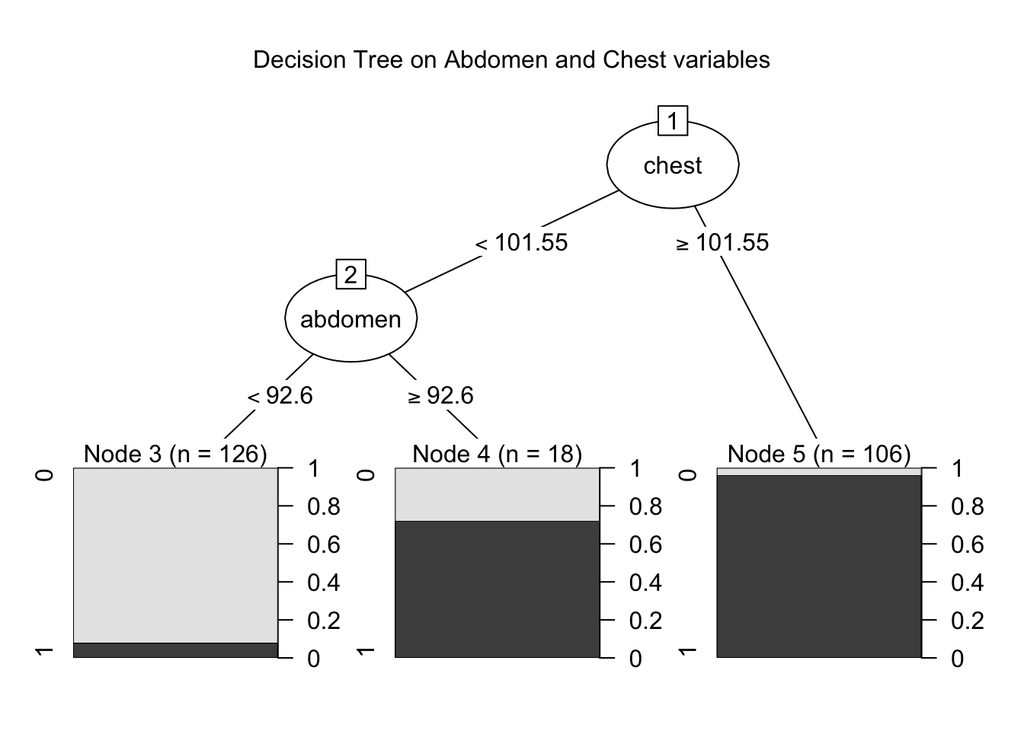

```r
plot(as.party(ov_tree), main="Decision Tree on Abdomen and Chest variables")
```

Out of a total of 250 observations, **96%** of people with a chest circumference greater or equal to 101.55cm are overweight. Also, of the people with a chest circumference less than 101.55cm, those with an abdomen circumference greater or equal to 92.6cm are **72%** likely to be overweight. On the other hand, those with an abdomen circumference less than 92.6cm are **92%** likely to be non-overweight.

## 3. Limitations

1. Gender Bias
2. Privacy Issues
3. Age Range

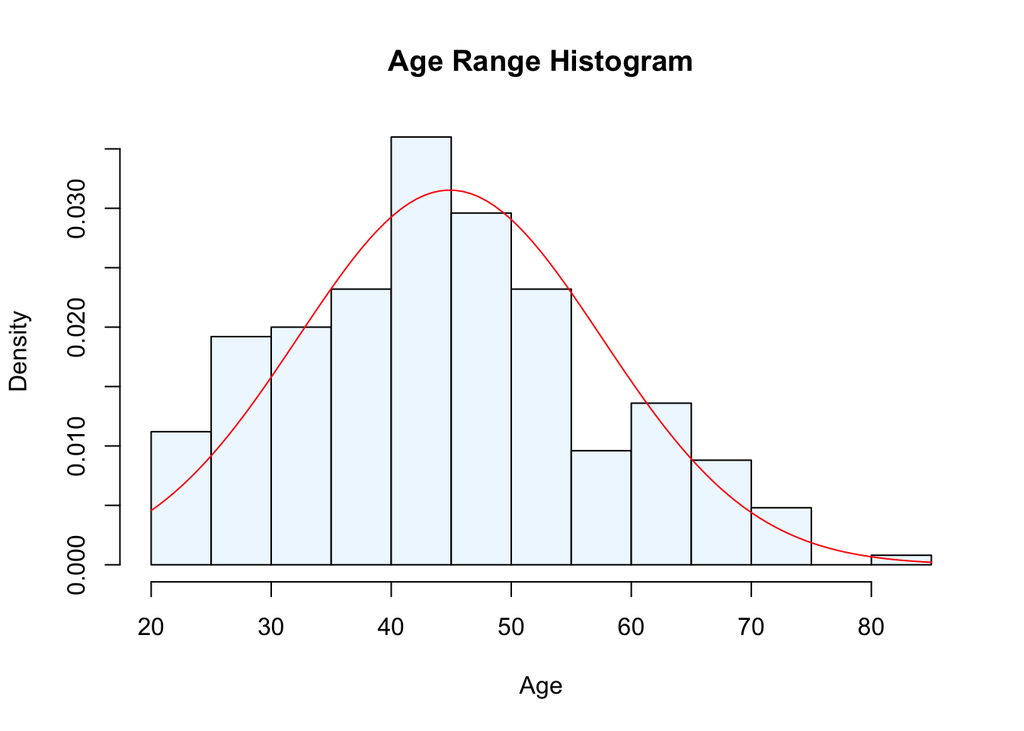

```r
hist(data$age, freq=FALSE, col="aliceblue", xlab="Age", main="Age Range Histogram")
curve(dnorm(x, mean=mean(data$age), sd=sd(data$age)), add=TRUE, col="red") #line
```

4. Multicollilinearity

## 5. References

1. Australian Institute of Health and Welfare (AIHW). (2019). Overweight & obesity. Australian Government. Retrieved from https://www.aihw.gov.au/reports-data/behaviours-risk-factors/overweight-obesity/overview
2. DASL. (n.d.). Bodyfat. DASL. Retrieved from < https://dasl.datadescription.com/datafile/bodyfat>
3. Rahman, A., & Harding, A. (2013). Prevalence of overweight and obesity epidemic in Australia: some causes and consequences. JP Journal of Biostatistics, 10(1), 31-48.
4. Stein, C. J., & Colditz, G. A. (2004). The epidemic of obesity. The Journal of Clinical Endocrinology & Metabolism, 89(6), 2522-2525.
5. Avinash, N. (2018). Understanding Logistic Regression in Python. DataCamp. Retrieved from https://www.datacamp.com/community/tutorials/understanding-logistic-regression-python
6. Nagesh S. C. (n.d.). Real world implementation of Logistic Regression. Medium. Retrieved from https://towardsdatascience.com/real-world-implementation-of-logistic-regression-5136cefb8125